# Análisis Champions League 2021 2022

Isaias Arcos y Nicolás Bejarano

23/10/2023

[figure not shown]

```r
library(tidyverse)
library(knitr)
library(kableExtra)
attacking <- read.csv("data/attacking.csv")
attempts <- read.csv("data/attempts.csv")
defending <- read.csv("data/defending.csv")
goalkeeper <- read.csv("data/goalkeeping.csv")
midfielders <- read.csv("data/distributon.csv")
goals <- read.csv("data/goals.csv")


# cambio de nombres dataset portero
goalkeeper <- goalkeeper %>%
  rename(
    Serial = serial,
    Nombre_jugador = player_name,
    Equipo = club,
    Posicion = position,
    Paradas = saved,
    Goles_concedidos = conceded,
    Penales_parados = saved_penalties,
    Partidos_sin_goles = cleansheets,
    #Despejes = punches_made,
    Partidos_jugados = match_played
  )


# cambio de nombres dataset defensa
defending <- defending %>%
  rename(
    serial = serial,
    Nombre_jugador = player_name,
    Equipo = club,
    Posicion = position,
    Balones_recuperados = balls_recoverd,
    Entradas = tackles,
    Entradas_ganadas = t_won,
    Entradas_perdidas = t_lost,
    Despejes_intentados = clearance_attempted,
    Partidos_jugados = match_played
  )

# medio campo
midfielders <- midfielders %>%
  rename(
    serial = serial,
    Nombre_jugador = player_name,
    Equipo = club,
    Posicion = position,
    Precisión_pase = pass_accuracy,
    Pases_intentados = pass_attempted,
    Pases_completados = pass_completed,
    Precisión_centro = cross_accuracy,
    Centros_intentados = cross_attempted,
    Centros_completados = cross_complted
  )

# renombrar variables de goles
goals <- goals %>%
  rename(
    serial = serial,
    nombre_jugador = player_name,
    equipo = club,
    posicion = position,
    goles = goals,
    pie_derecho = right_foot,
    pie_izquierdo = left_foot,
    cabezazos = headers,
    otros = others,
    dentro_area = inside_area
  )
```

El fútbol es un deporte colectivo y de altísima complejidad por lo que es importante analizar todas las fasetas del juego:

- Arco
- Defensa
- Medio campo
- Ataque

# Análisis de porteros

Las salvadas así como intervenciones importantes prácticamente son un “gol” para el equipo, por lo que si el arquero está en un gran nivel sin duda ayuda mucho en una competición corta como esta.

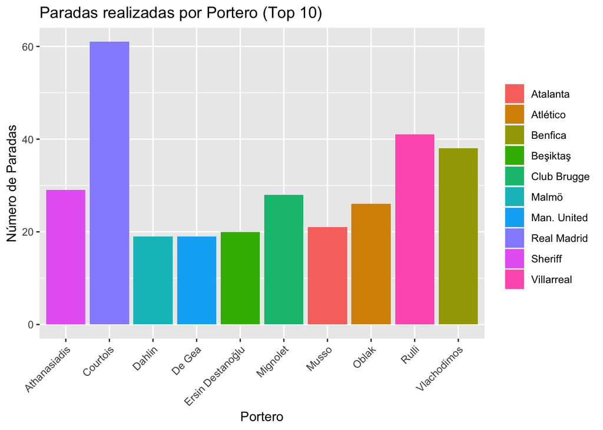

```r
top_goalkeepers <- goalkeeper %>%
  arrange(desc(Paradas)) %>%
  head(10)

ggplot(top_goalkeepers, aes(x=Nombre_jugador, y=Paradas, fill=Equipo)) +
  geom_bar(stat="identity", position="dodge") +
  theme(axis.text.x = element_text(angle = 45, hjust = 1)) +
  labs(title="Paradas realizadas por Portero (Top 10)",
       x="Portero",
       y="Número de Paradas") +
  theme(legend.title=element_blank())  # Esto retira la leyenda
```

Vemos claramente que Courtois es el claro ganador, pero esto se puede deber a que jugó más partidos, vamos a realziar un análisis más profundo, para medir el rendimiento de los porteros dependiendo de la cantidad de participaciones.

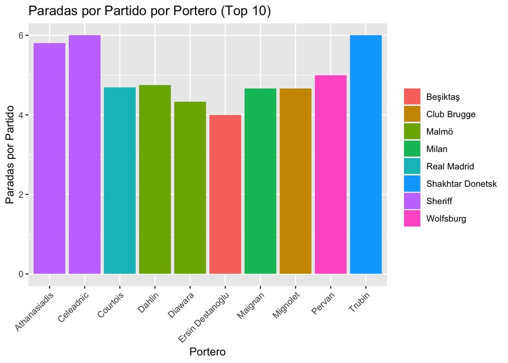

```r
# creamos una nueva métrica
goalkeeper <- goalkeeper %>%
  mutate(Paradas_por_partido = Paradas / Partidos_jugados) %>%
  arrange(desc(Paradas_por_partido)) %>%
  head(10)

ggplot(goalkeeper, aes(x=Nombre_jugador, y=Paradas_por_partido, fill=Equipo)) +
  geom_bar(stat="identity", position="dodge") +
  theme(axis.text.x = element_text(angle = 45, hjust = 1)) +
  labs(title="Paradas por Partido por Portero (Top 10)",
       x="Portero",
       y="Paradas por Partido") +
  theme(legend.title=element_blank())
```

Realizando este análisis vemos que aún así Courtois sigue estando entre los mejores sin embargo los porteros *Trubin* del *Sharkhtar Donest* y *Celeadnic* de *Sherif* también han tenido un alto rendimiento.

# Análisis de defensa

Primero obtenemos las estadísticas generales de la competición en el apartado defensivo

## Recuperaciones de balón

Las recuperaciones de balón son fundamentales pues permiten interrumpir un ataque rival y recuperar la poseción del balón o armar un contra ataque, aquí observamos el **Top 10 jugadores** con mayores recuperaciones de balón.

```r
top_balls_recovered <- defending %>%
  arrange(desc(Balones_recuperados)) %>%
  head(10) %>%
   select(Nombre_jugador, Equipo, Balones_recuperados)
#print(top_balls_recovered)
kable(top_balls_recovered, "html") %>%
kable_styling()
```

| Nombre_jugador | Equipo | Balones_recuperados |
| --- | --- | --- |
| Casemiro | Real Madrid | 76 |
| Éder Militão | Real Madrid | 76 |
| Reinildo | Atlético | 76 |
| Fabinho | Liverpool | 74 |
| Albiol | Villarreal | 73 |
| Thiago Silva | Chelsea | 65 |
| Otamendi | Benfica | 63 |
| Capoue | Villarreal | 62 |
| Van Dijk | Liverpool | 62 |
| João Cancelo | Man. City | 56 |

## Distribución de entradas exitosas por equipo

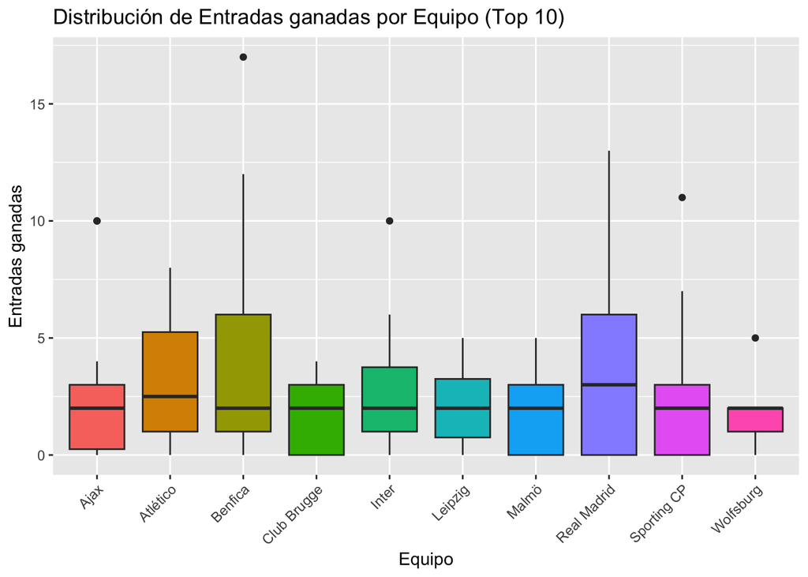

```r
# para evitar la carga cognitiva vamos a filtrar el top 10 equipos con más entradas exitosas
top_teams_success_tackles <- defending %>%
  group_by(Equipo) %>%
  summarize(mediana_entradas = median(Entradas_ganadas)) %>%
  arrange(desc(mediana_entradas)) %>%
  head(10) %>%
  pull(Equipo)

# Diagarama de cajas
defending %>%
  filter(Equipo %in% top_teams_success_tackles) %>%
  ggplot(aes(x=Equipo, y=Entradas_ganadas)) +
  geom_boxplot(aes(fill=Equipo)) +
  theme(axis.text.x = element_text(angle = 45, hjust = 1)) +
  labs(title="Distribución de Entradas ganadas por Equipo (Top 10)",
       x="Equipo",
       y="Entradas ganadas") +
  theme(legend.position="none") #elimina leyenda
```

# Análisis de medio campo

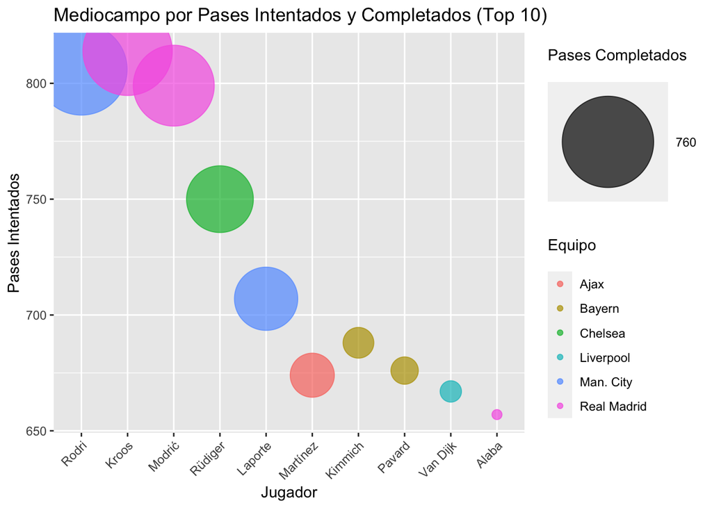

```r
# top de distribucion basados en nueva metrica
# pases compeltados e intentados
top_midfielders <- midfielders %>%
  mutate(Puntuacion_compuesta = Pases_intentados * Pases_completados) %>%
  arrange(desc(Puntuacion_compuesta)) %>%
  head(10)

# establecer top para leyenda de burbuja pases completados
tres_tamanos_maximos <- sort(unique(top_midfielders$Pases_completados), decreasing = TRUE)[1:1]

ggplot(top_midfielders, aes(x=reorder(Nombre_jugador, -Puntuacion_compuesta), y=Pases_intentados, size=Pases_completados, color=Equipo)) +
  geom_point(alpha=0.7) +
  scale_size_continuous(range = c(3, 30), breaks=tres_tamanos_maximos) +
  labs(
    title="Mediocampo por Pases Intentados y Completados (Top 10)",
    x="Jugador",
    y="Pases Intentados",
    size="Pases Completados",
    color="Equipo"
  ) +
  theme(axis.text.x = element_text(angle = 45, hjust = 1),
        legend.position = "right",
        legend.spacing.y = unit(0.5, "cm")) +
  guides(size=guide_legend(order=1), color=guide_legend(order=2))
```

En este gráfico se puede apreciar el top de futbolistas con mayor cantidad de pases intentados y su relación con pases completados con éxito.

## Análisis de delanteros

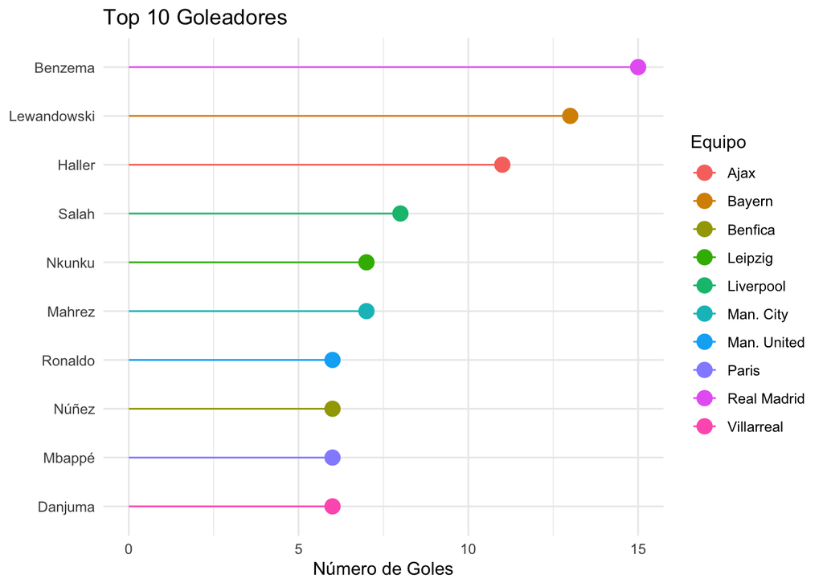

```r
top_goleadores <- goals %>%
  arrange(desc(goles)) %>%
  head(10)

ggplot(top_goleadores, aes(x=reorder(nombre_jugador, goles), y=goles, color=equipo)) +
  geom_segment(aes(xend=nombre_jugador, yend=0, color=equipo), size=0.5) +
  geom_point(size=4) +
  coord_flip() +
  labs(
    title="Top 10 Goleadores",
    y="Número de Goles",
    x="Jugador"
  ) +
  theme_minimal() +
  theme(axis.title.y=element_blank()) +
  scale_color_discrete(name="Equipo")
```

Como podemos observar el podio se lo llevan Benzema, Lewandowski y Haller.

# Conclusiones

En la temporada 2021-2022 el equipo ganador fue el Real Madrid, si realizamos un análisis detallado es un más que justo ganador, obteniendo podio en todas las fasetas del campo, se puede destacar el volúmen de pases intentados/exitosos de sus medio campistas Kroos Y Modric, así como también una temporada que roza la gloria de Benzema y Courtois.

Como apartado adicional jugadores muy interesantes son Haller, debido a la cantidad de goles marcados a pesar de no haber tenido tantas participaciones. Kimmich a pesar de no haber llegado a la final tienen una gran cantidad de pases intentados y un gran volumen de acierto, además de ser un jugador que no solo da pases “defensivos”.

[figure not shown]